# Visualización de datos con {ggplot2} II

Hasta ahora, visualizamos los datos tal cual vienen en la base de datos o con ayuda de {dplyr} para transformarlos. Pero como adelantamos con `geom_smooth()`, hay ciertas transformaciones comunes que se pueden hacer usando {ggplot2}.

De paso vamos a usar datos incluidos en el paquete `datos` (muchos paquetes traen bases de datos para probar cosas, ¡este en particular son todas bases de datos en español!) que podés descargar como siempre con `install.packages("datos")`. Los datos `diamantes` contiene información sobre ~ 54000 diamantes, incluido el `precio`, el `quilate`, el `color`, la `claridad` y el `corte` de cada uno.

```r
library(ggplot2)
library(dplyr)
library(datos)
str(diamantes)
```

```
## tibble [53,940 × 10] (S3: tbl_df/tbl/data.frame)
##  $ precio     : int [1:53940] 326 326 327 334 335 336 336 337 337 338 ...
##  $ quilate    : num [1:53940] 0.23 0.21 0.23 0.29 0.31 0.24 0.24 0.26 0.22 0.23 ...
##  $ corte      : Ord.factor w/ 5 levels "Regular"<"Bueno"<..: 5 4 2 4 2 3 3 3 1 3 ...
##  $ color      : Ord.factor w/ 7 levels "D"<"E"<"F"<"G"<..: 2 2 2 6 7 7 6 5 2 5 ...
##  $ claridad   : Ord.factor w/ 8 levels "I1"<"SI2"<"SI1"<..: 2 3 5 4 2 6 7 3 4 5 ...
##  $ profundidad: num [1:53940] 61.5 59.8 56.9 62.4 63.3 62.8 62.3 61.9 65.1 59.4 ...
##  $ tabla      : num [1:53940] 55 61 65 58 58 57 57 55 61 61 ...
##  $ x          : num [1:53940] 3.95 3.89 4.05 4.2 4.34 3.94 3.95 4.07 3.87 4 ...
##  $ y          : num [1:53940] 3.98 3.84 4.07 4.23 4.35 3.96 3.98 4.11 3.78 4.05 ...
##  $ z          : num [1:53940] 2.43 2.31 2.31 2.63 2.75 2.48 2.47 2.53 2.49 2.39 ...
```

## Gráficos de frecuencias

Este es un gráfico de barras construido usando la función `geom_bar()`. En el eje x muestra el `corte` de los diamantes y en el eje y la cantidad (*count* en inglés) de diamantes en cada categoría. Pero `diamantes` no tiene una variable que se llame `count` y tampoco la generamos nosotros. ¡Es calculada internamente por {ggplot2}!

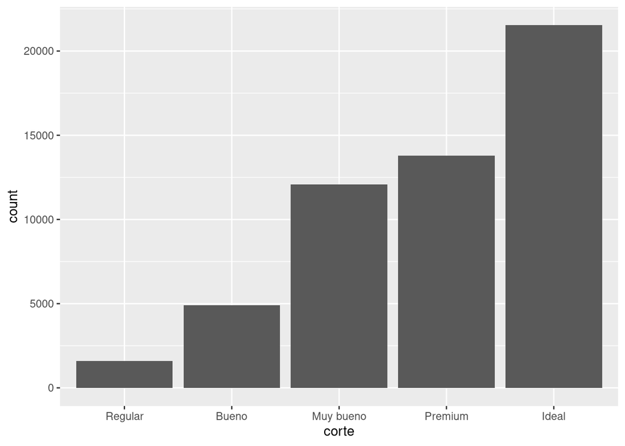

```r
ggplot(data = diamantes, aes(x = corte)) +
  geom_bar()
```

Cómo el gráfico de barras, también podemos graficar histogramas con `geom_histogram()` y polígonos de frecuencia con `geom_density()` para visualizar la cantidad de observaciones que caen en cada categoría (si la variable es discreta como el caso del corte de los diamantes) o rango de valores (para variables continuas).

Un ejemplo de variable continua es el `precio` de los diamantes, veamos como se ve un histograma y de paso le cambiamos el color a las barras, pero ojo, solo al borde.

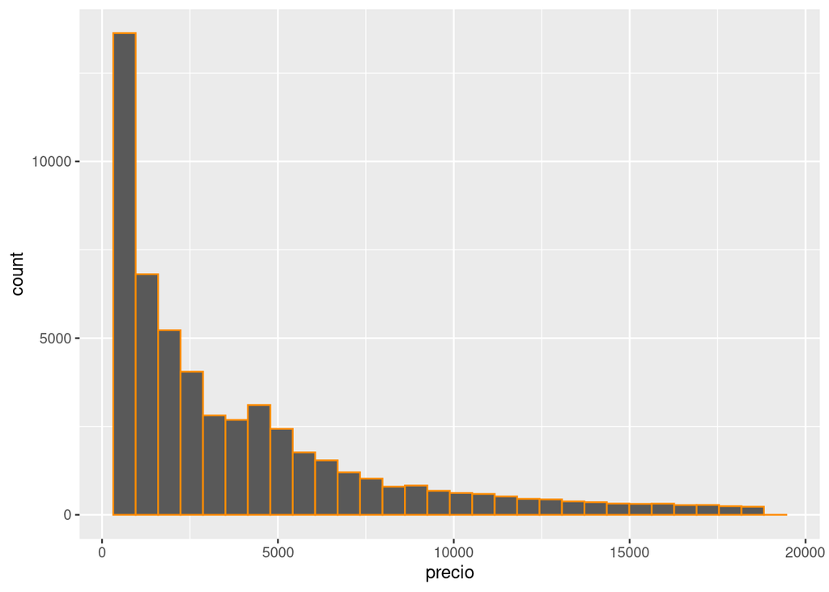

```r
ggplot(diamantes, aes(precio)) +
  geom_histogram(color = "darkorange")
```

> **Primer desafío**

> ¿Notaste el mensaje que devuelve el gráfico?

> ``stat_bin()` using `bins = 30`. Pick better value with > `binwidth`.`

> Esta geometría tiene dos argumentos importantes `bins` y > `binwidth`. Cambiá el valor de alguno de los dos argumentos y volvé > a generar el gráfico, ¿que rol juegan los argumentos?

> También podés revisar la documentación. ***

Además de contar la cantidad de elementos, {ggplot2} puede calcular muchas otras transformaciones sobre los datos. Por ejemplo si quisiéramos el porcentaje o la proporción que le corresponde a cada categoría de `corte` respecto del total podemos hacerlo *mapeando* esa transformación `prop` al eje y con la función `stat()`.

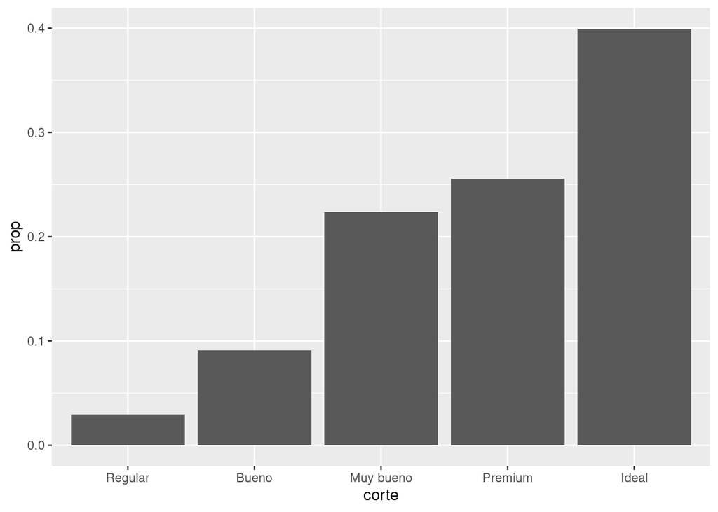

```r
ggplot(data = diamantes, aes(x = corte)) +
  geom_bar(aes(y = stat(prop), group = 1))
```

Fijate que la variable `prop` no es una columna de `diamantes` sino que es el nombre de una variable computada por `geom_bar()`, por eso hay que rodearla de la función `stat()`. El nombre de las variables computadas por cada geoms está en su documentación (abajo de todo, antes de los ejemplos).

Ahora podríamos decir que el 40% de los diamantes en la base de datos tienen un corte *ideal*. Además de la función `stat()` agregamos `group = 1` y esto no fue sin querer. Probá correr el gráfico sin ese argumento.

Al incluir `group = 1`, {ggplot2} junta todas las observaciones en un único grupo (con el valor `1`) y calcula la proporción o el porcentaje que representa cada corte respecto del total de diamantes. Si no incluimos eso, {ggplot2} asumirá que cada categoría de corte es un grupo independiente y el cálculo del porcentaje también lo hará por separado.

### Posición

Ya vimos que la estética del `color` sólo modifica el borde de las barras, si quisieras modificar el relleno necesitamos cambiar el `fill` y al igual que antes podemos *mapear* una variable a esta estética.

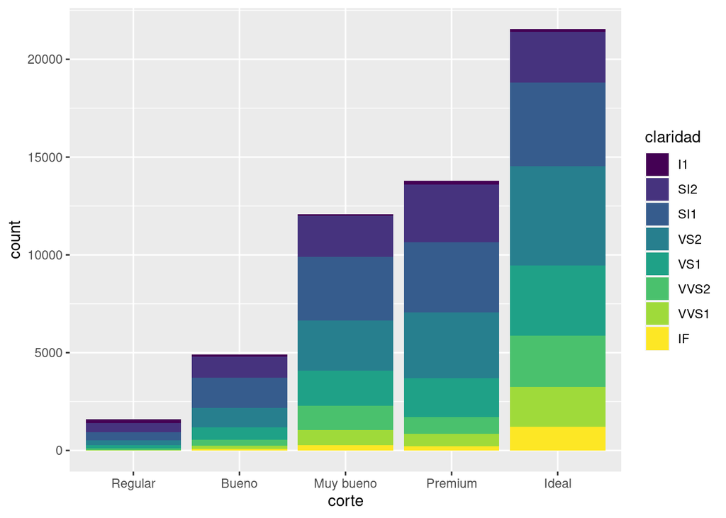

```r
ggplot(data = diamantes) +
  geom_bar(aes(x = corte, fill = claridad))
```

Al *mapear* una variable distinta, la claridad de los diamantes, podemos visualizar información extra. Este “apilamiento” de las barras es la opción de posición por defecto `position = "stack"`, pero podrías usar una de las otras tres opciones: `"identity"`, `"dodge"` o `"fill"`.

- `position = "identity"` colocará cada barra comenzando en cero quedando todas superpuestas. Para ver esa superposición, debemos hacer que las barras sean ligeramente transparentes configurando el `alpha` a un valor pequeño.

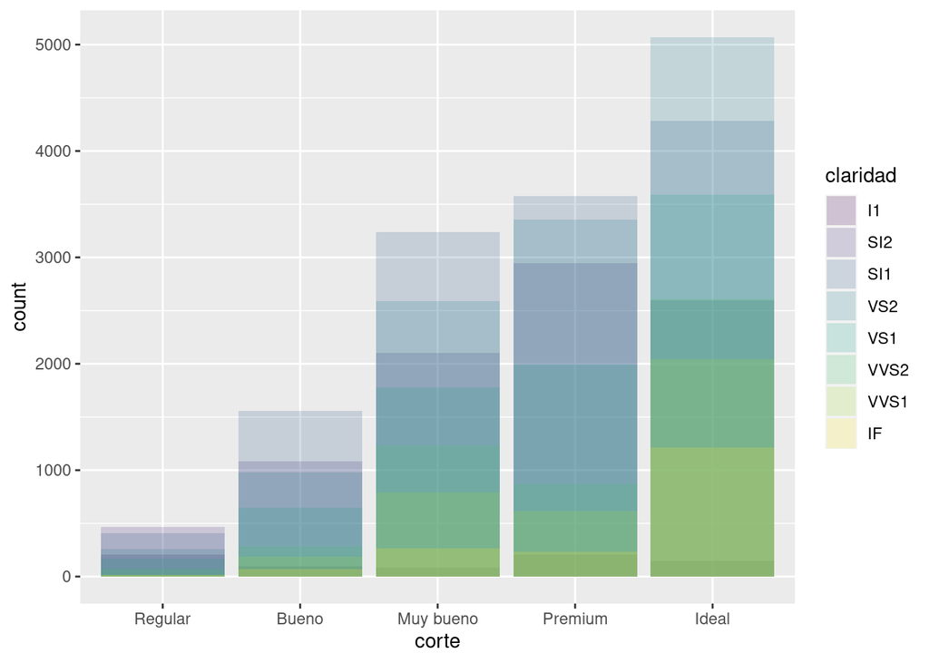

```r
ggplot(diamantes) +
  geom_bar(aes(x = corte, fill = claridad), alpha = 0.2, position = "identity")
```

- `position = "fill"` apila las barras al igual que `position = "stack"`, pero transforma los datos para que cada conjunto de barras apiladas tenga la misma altura. Esto hace que sea más fácil comparar proporciones entre grupos.

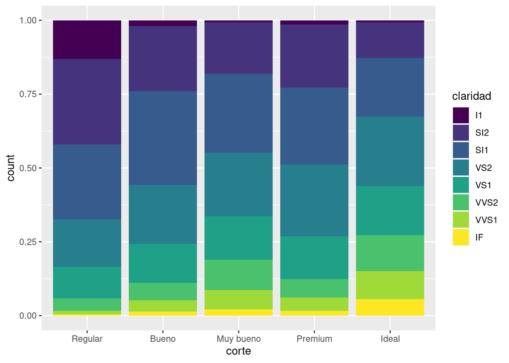

```r
ggplot(diamantes) +
  geom_bar(aes(x = corte, fill = claridad), position = "fill")
```

- `position = "dodge"` coloca las barras una al lado de la otra. Esto hace que sea más fácil comparar valores individuales.

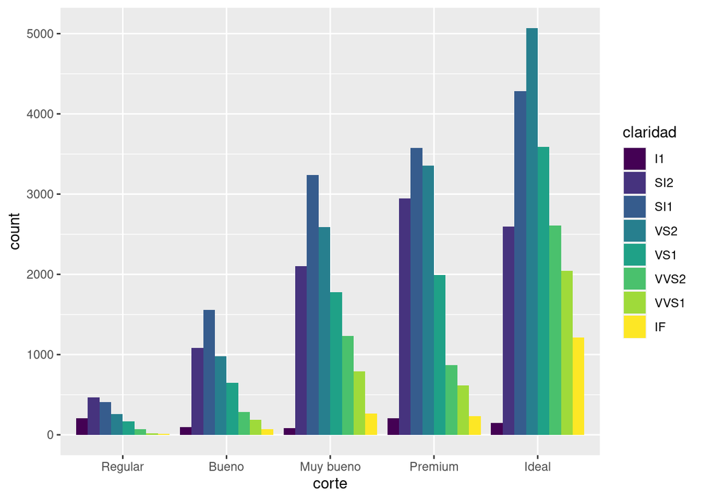

```r
ggplot(diamantes) +
  geom_bar(aes(x = corte, fill = claridad), position = "dodge")
```

## Gráficos de líneas suavizas

Cómo vimos antes, los gráficos de líneas suavizadas (smoothers) ajustan un modelo a los datos y luego grafican las predicciones del modelo. Sin entrar en muchos detalles, se puede aplicar distintos modelos y la elección del mismo dependerá de los datos.

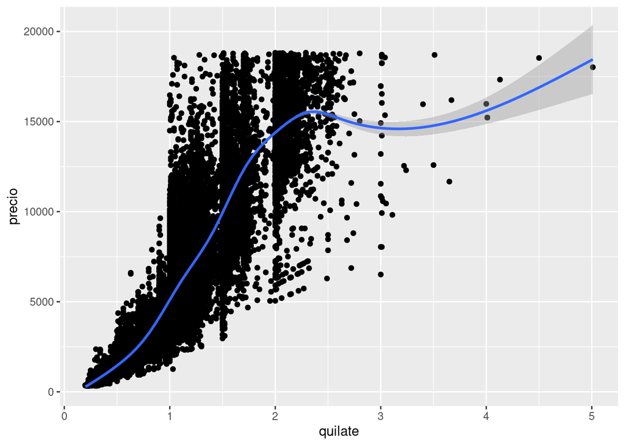

```r
ggplot(diamantes, aes(quilate, precio)) +
  geom_point() +
  geom_smooth()
```

## Gráficos de caja

Los diagramas de caja, mejor conocidos como boxplots calculan un resumen robusto de la distribución y luego muestran una caja con formato especial.

La línea central de la caja corresponde a la **mediana** (el valor que toma el dato central) y los extremos de la caja son los **cuartiles 1 y 3**, definiendo así el **rango intercuartil** (IQR). Los extremos están definidos como el valor observado que no esté más lejos de **1.5*IQR** de la mediana y los puntos son los las observaciones que se escapan de ese rango, que pueden ser considerados **outliers** o **valores extremos**.

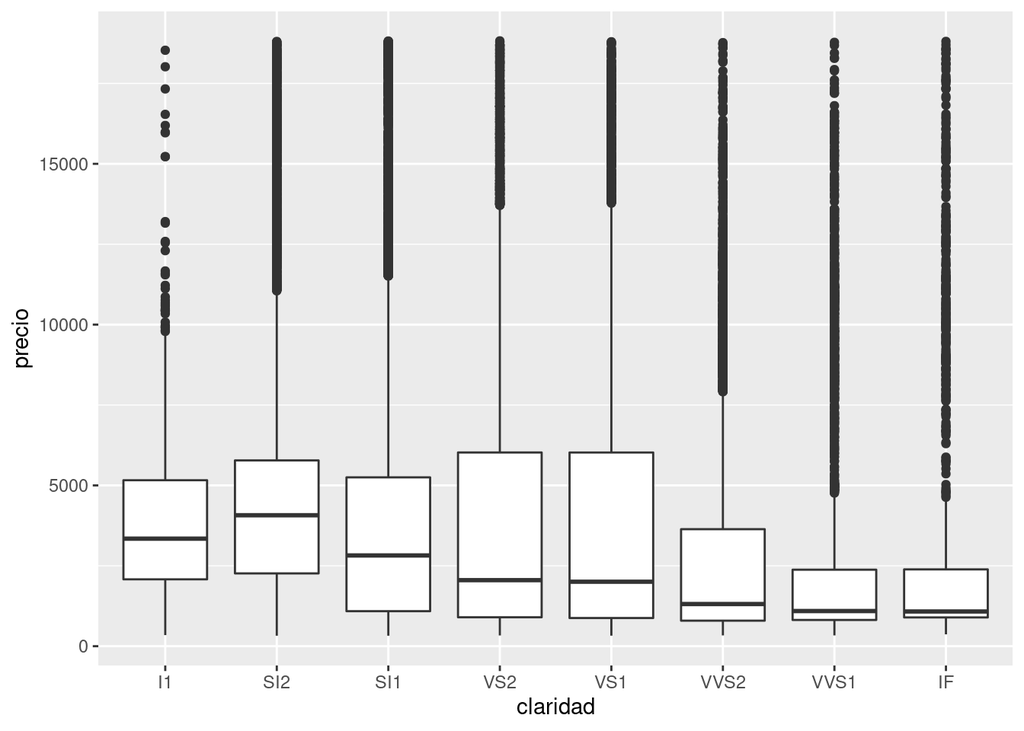

```r
ggplot(diamantes, aes(claridad, precio)) +
  geom_boxplot()
```

Los boxplot dan muchísima información sobre los datos pero al mismo tiempo *esconden* la cantidad de observaciones que se usaron para generarlos y en particular cual es la frecuencia a lo largo del eje y. Por esta razón también existen `geom_violin()` y `geom_jitter()`.

> **Segundo desafío**
> 1. Volvé a graficar la distribución del precio para cada tipo de > claridad pero ahora usando `geom_violin()` y `geom_jitter()`.
> 2. ¿Qué ventajas y desventajas encuentran respecto de `geom_boxplot()`? ***

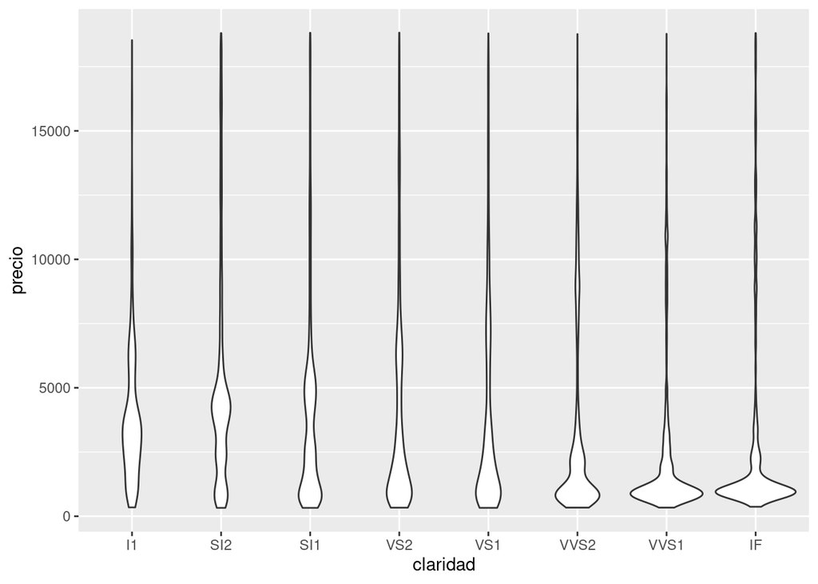

```r
ggplot(diamantes, aes(claridad, precio)) +
  geom_violin()
```

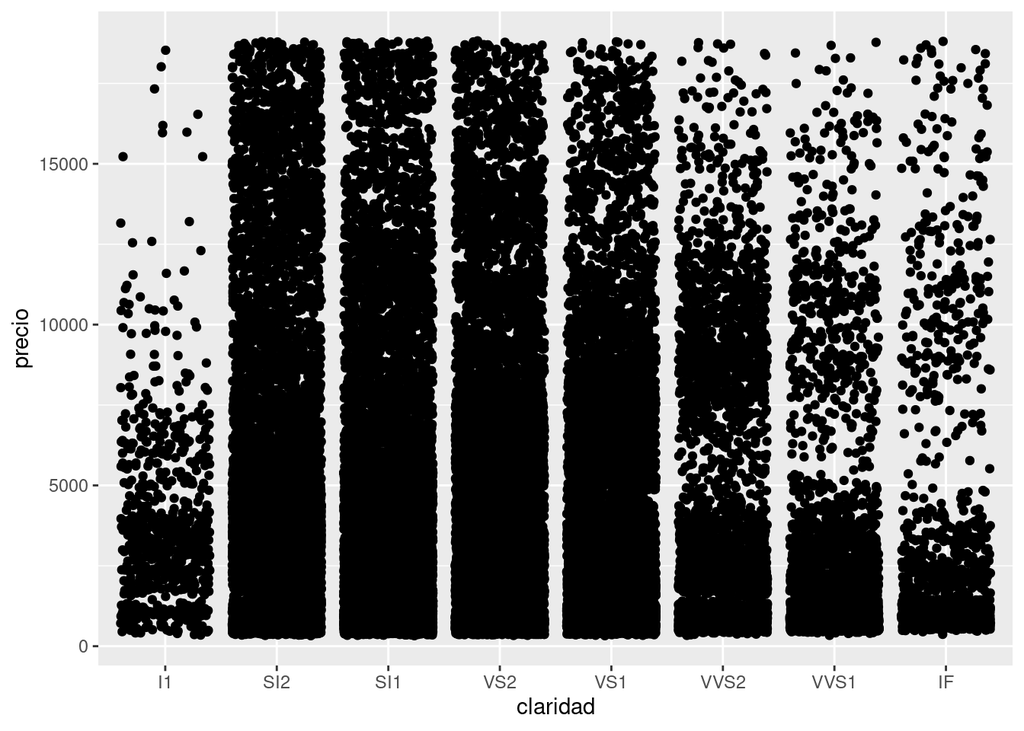

```r
ggplot(diamantes, aes(claridad, precio)) +
  geom_jitter()
```

> > Cuando nuestra base de datos es muy grande corremos el riesgo de generar de que los elementos del gráfico estén tan juntos que se solapen y no se vean. Esto se conoce como **overplotting**. La base de datos `diamantes` tiene 53940 observaciones y al graficar un punto por cada una, aún si están separados por la claridad, quedan superpuestos.

> > Para resolver este problema se suele modificar la estética de los elementos, cambiando el tamaño o `size` para que ocupen menos lugar y se vean mejor, cambiando la forma o `shape` por alguna que no tenga relleno y permita ver los elementos que hay atrás o modificando la transparencia o `alpha` por la misma razón. En bases de datos tan grandes como la de diamantes, muchas veces hay que utilizar varios de estos recursos.

## Graficando en múltiples paneles

Vimos que es posible graficar más de dos variables en un gráfico *mapeando* una variable al `color` o por ejemplo el tipo de línea o `linetype`

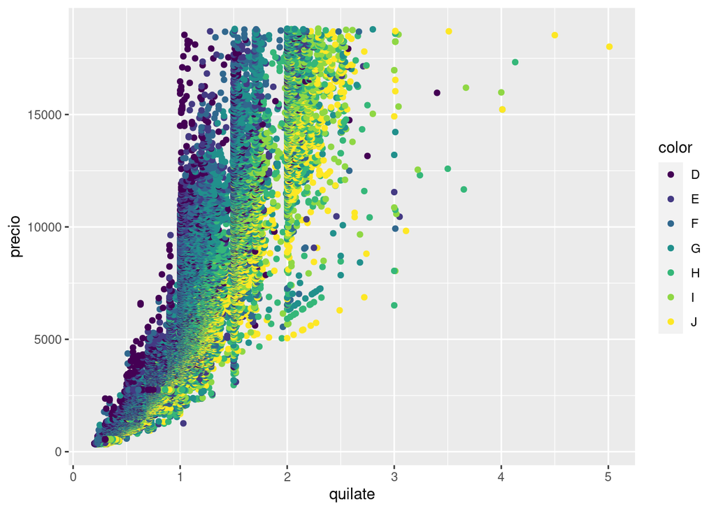

```r
ggplot(diamantes, aes(quilate, precio)) +
  geom_point(aes(color = color))
```

En este caso no solo visualizamos la relación entre el precio y el quilate del diamante, también podemos ver que rol juega el color. También podríamos haber intentando resolver el problema generando un gráfico por cada color filtrando las observaciones correspondientes.

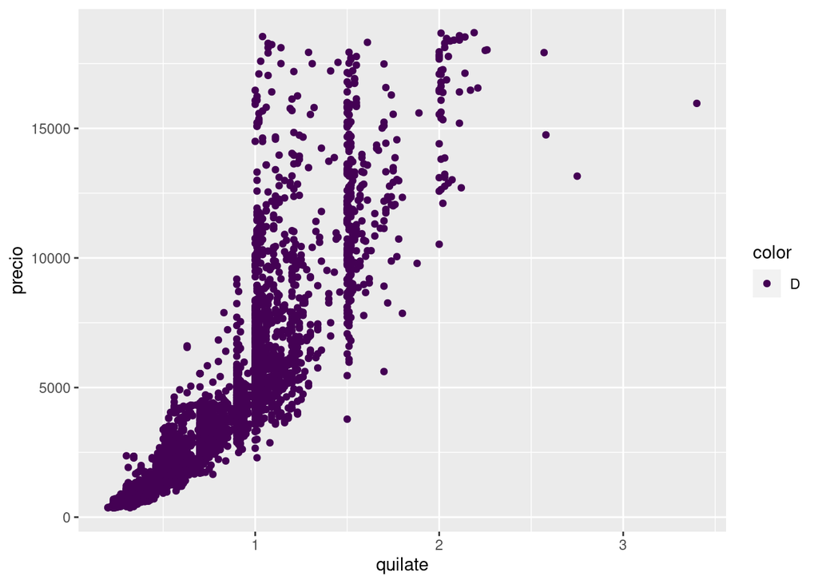

```r
diamantes %>%
  filter(color == "D") %>%
  ggplot(aes(quilate, precio)) +
  geom_point(aes(color = color))
```

Pero sería muchísimo trabajo si tenemos que hacer esto para cada una de las 7 categorías de color. La buena noticia es que {ggplot2} tiene un par de funciones justo para resolver este problema:

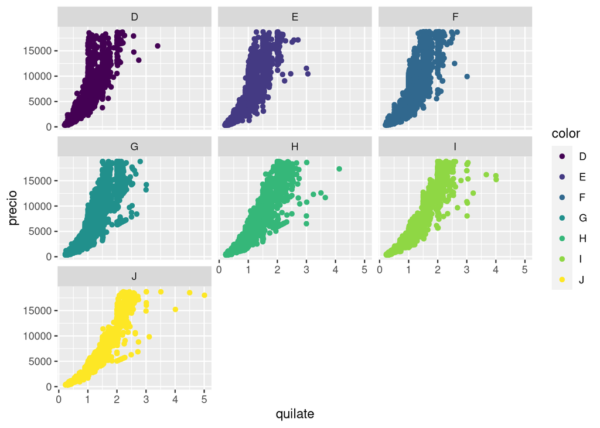

```r
ggplot(diamantes, aes(quilate, precio)) +
  geom_point(aes(color = color)) +
  facet_wrap(~color)
```

Esta nueva capa con `facet_wrap()` divide al gráfico inicial en 7 paneles o *facets*, uno por cada color. Esta función requiere saber que variable será la responsable de separar los paneles y para eso se usa la **notación de funciones** de R: `~color`. Esto se lee como generar paneles *“en función del color”*.

¿Y si quisiéramos generar paneles a partir de 2 variables? Para eso existe `facet_grid()`. En este gráfico generamos paneles viendo la *“relación entre el corte y el color”* y por ejemplo en el primer panel arriba a la izquierda podremos observar los diamantes que son al mismo tiempo de color D y corte Regular. En este caso *mapear* la variable color al color de los diamantes no parece ser necesario ya que cada columna ya nos permite identificar eso, sin embargo en algunos casos ayuda a leer el gráfico más rápido.

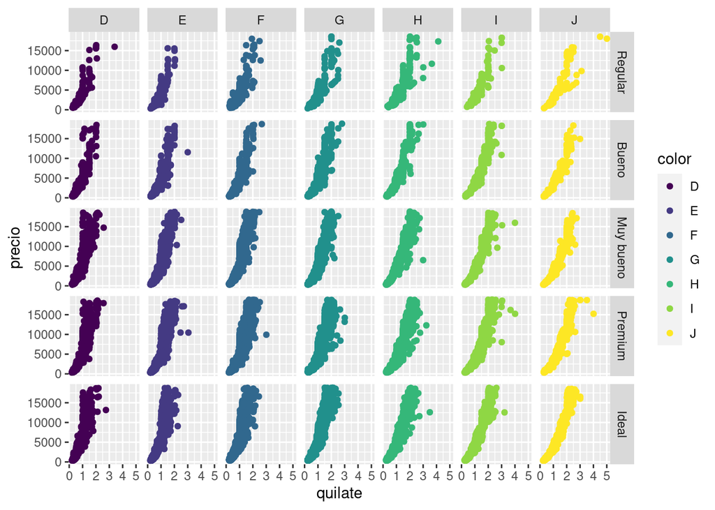

```r
ggplot(diamantes, aes(quilate, precio)) +
  geom_point(aes(color = color)) +
  facet_grid(corte~color)
```

> **Tercer desafío**

> Generá boxplots para analizar como se comporta el `precio` según la `claridad` para cada tipo de `corte` como se ve acá.

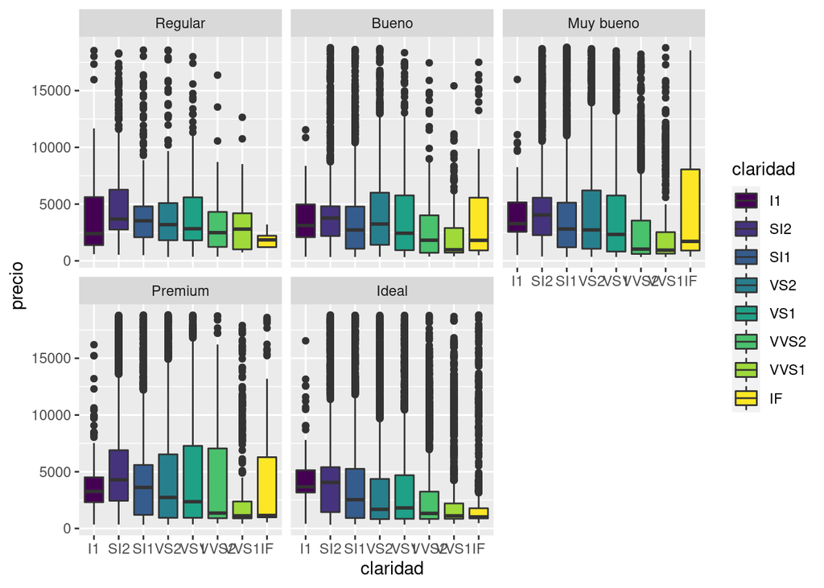

***

**Fuente:** Estos apuntes forman parte del curso de Excel a R paocorrales.github.io/deExcelaR de Elio Campitelli y Paola Corrales con licencia Creative Commons Attribution-ShareAlike 4.0.